# PM 579: Statistical Analysis of High-Dimensional Data | Homework 2

Saket Choudhary skchoudh@usc.edu

6/9/2016

## Reading data

```r
library(limma)
library(knitr)
library(sva)
sfiles <- c('../data/Stallcup/mySample Probe Profile FinalReport.txt')
cfiles <- c('../data/Stallcup/myControl Probe Profile FinalReport.txt')
rawdata = read.ilmn(files=sfiles, ctrlfiles=cfiles)
```

```
## Reading file ../data/Stallcup/mySample Probe Profile FinalReport.txt ... ...
## Reading file ../data/Stallcup/myControl Probe Profile FinalReport.txt ... ...
```

## Sanity Checks

```r
dim(rawdata$E)
```

```
## [1] 25209    48
```

```r
(table(rawdata$genes$Status))
```

```
##
##             BIOTIN            CY3_HYB       HOUSEKEEPING
##                  2                  6                  1
##           LABELING LOW_STRINGENCY_HYB           NEGATIVE
##                  2                  8                664
##            regular
##              24526
```

## Read targets

```r
## Read targets
targetfile <- '../data/Stallcup/SampleChars.csv'
targets <- read.csv(targetfile, row.names = 1)
## Assign targets to raw data
rawdata$targets=targets[colnames(rawdata),]
## Sanity Check
head(rawdata$targets)
```

```
##              treatment time
## 4849554032_A  Control2    1
## 4849554032_B         X    2
## 4849554032_C         X    3
## 4849554032_D         X    1
## 4849554032_E  Control2    1
## 4849554032_F         X    2
```

```r
kable(table(rawdata$targets$treatment, rawdata$targets$time) )
```

|  | 1 | 2 | 3 |
| --- | --- | --- | --- |
| Control1 | 4 | 4 | 4 |
| Control2 | 4 | 4 | 4 |
| X | 4 | 4 | 4 |
| Y | 4 | 4 | 4 |

## QC Figures

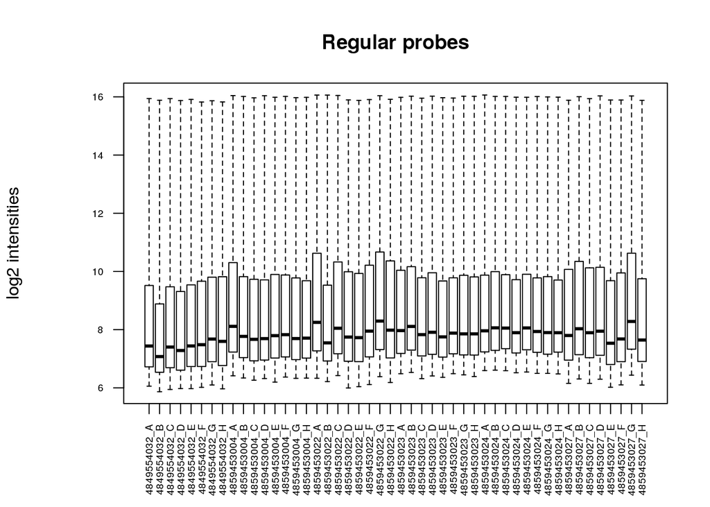

```r
stemplot <- function(x,y,xlabels,pch=16,linecol=1,clinecol=1,...){
if (missing(y)){
    y = x
    x = 1:length(x) }
    plot(x,y,xaxt="n", pch=pch,...)

    for (i in 1:length(x)){
       lines(c(x[i],x[i]), c(0,y[i]),col=linecol)
    }
    lines(c(x[1]-2,x[length(x)]+2), c(0,0),col=clinecol)
    axis(1, at=1:length(xlabels),
         labels=xlabels,
         cex.axis=0.6,
         las=2)
}
par(mar=c(5,6,4,2)+0.1)
par(mgp=c(5,1,0))

boxplot(log2(rawdata$E[rawdata$genes$Status=="regular",]),
        range=0,
        xlab="Arrays",
          ylab="log2 intensities",
        main="Regular probes",
        cex.axis=0.6,
        las=2)
```

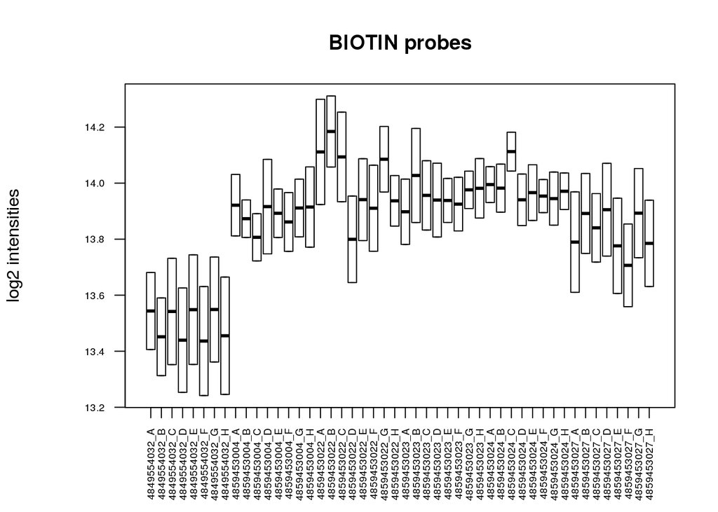

```r
boxplot(log2(rawdata$E[rawdata$genes$Status=="BIOTIN",]),
        range=0,
        xlab="Arrays",
          ylab="log2 intensities",
        main="BIOTIN probes",
        cex.axis=0.6,
        las=2)
```

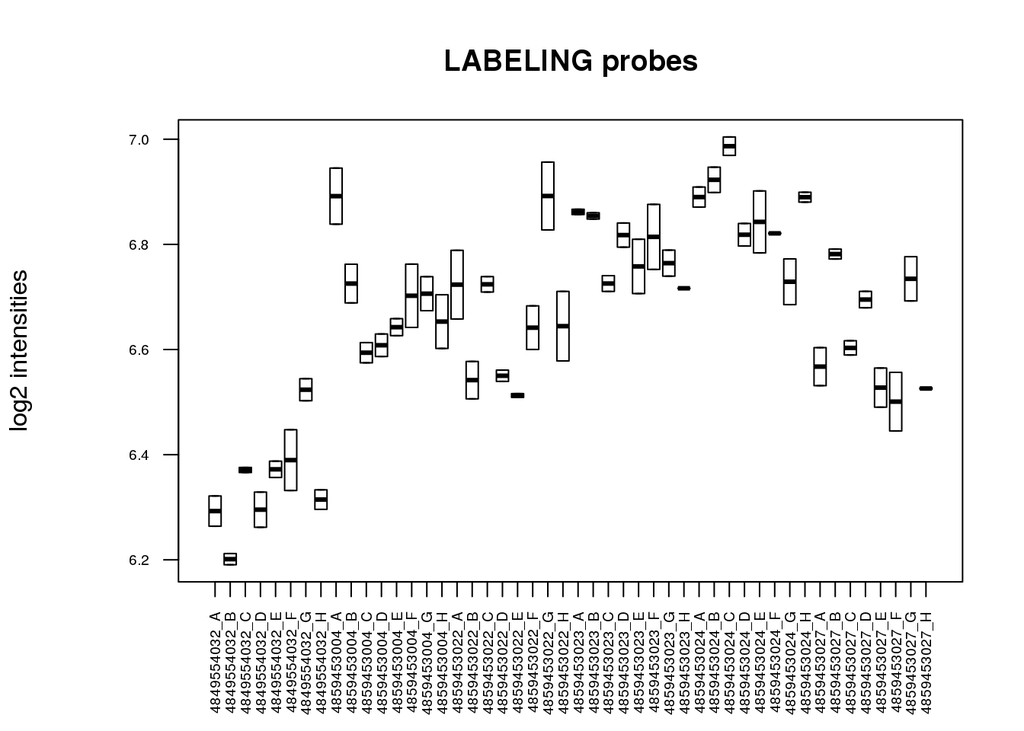

```r
boxplot(log2(rawdata$E[rawdata$genes$Status=="LABELING",]),
        range=0,
        xlab="Arrays",
          ylab="log2 intensities",
        main="LABELING probes",
        cex.axis=0.6,
        las=2)
```

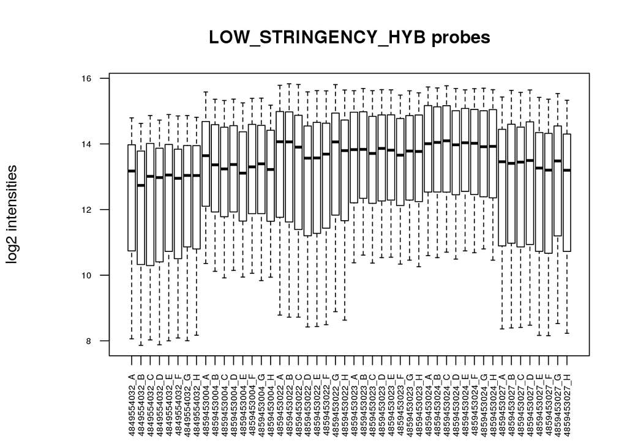

```r
boxplot(log2(rawdata$E[rawdata$genes$Status=="LOW_STRINGENCY_HYB",]),
        range=0,
        xlab="Arrays",
          ylab="log2 intensities",
        main="LOW_STRINGENCY_HYB probes",
        cex.axis=0.6,
        las=2)
```

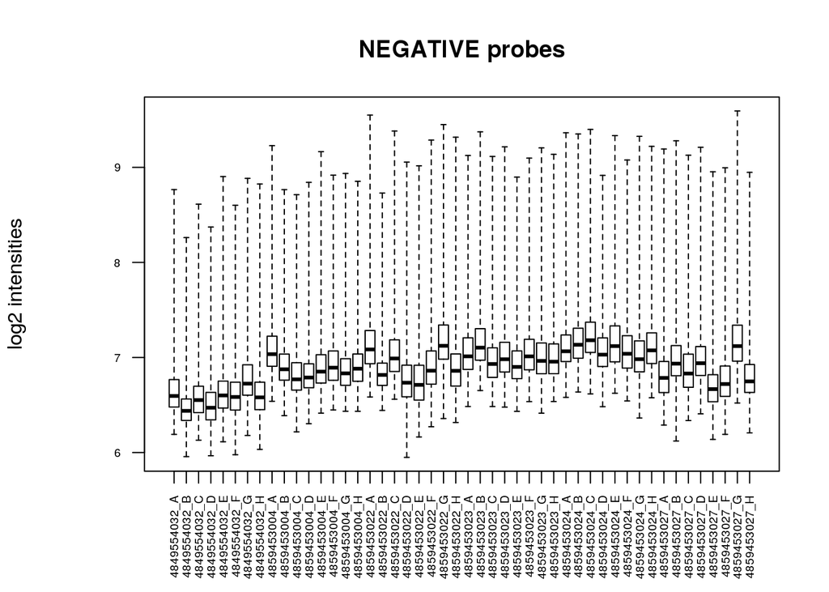

```r
boxplot(log2(rawdata$E[rawdata$genes$Status=="NEGATIVE",]),
        range=0,
        xlab="Arrays",
          ylab="log2 intensities",
        main="NEGATIVE probes",
        cex.axis=0.6,
        las=2)
```

There is only one housekeeping gene for every array, and hence we use a stem plot to look at the distribution

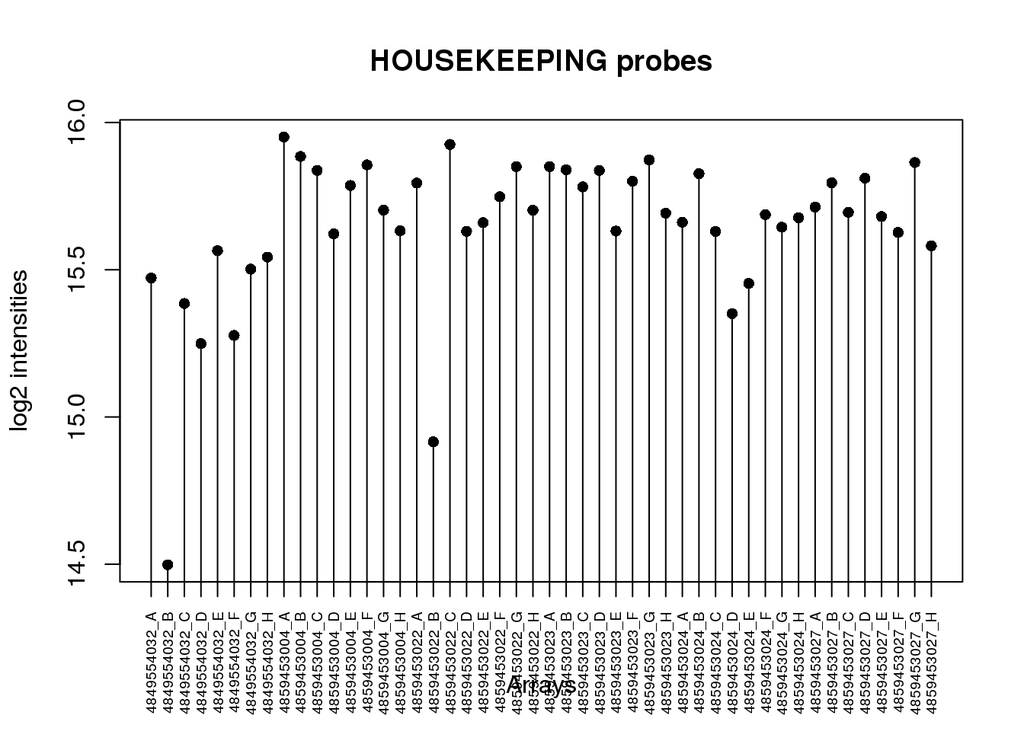

```r
stemplot(log2(rawdata$E[rawdata$genes$Status=="HOUSEKEEPING",]),
         xlab="Arrays",
           ylab="log2 intensities",
         xlabels = rownames(rawdata$targets),
         main="HOUSEKEEPING probes")
```

## QC Analysis discussion

From the QC plots, we observe that regular probes have similar distribution across arrays, the BIOTIN probes exhibit high intensities across arrays and also seem top exhibit array specific bias. Array specific bias is also evident from the LABELLING and LOW_STRINGENCY_HYB probes. There are 2 labelling probes on each array and they seem to have moderate intensities while exhibiting array specfic bias. The LOW_STRINGENCY_HYB probes show high intensity throughout which is expected but also exihibt array specific bias with lower intensities in the first and last 8 arrays. Negative probes also have array specific bias, but otherwise have low values throughout as compared to the regular probes which is expected.

Housekeeping probes have high expression throughout all arrays but exhibit array specific bias. A partivular caes is of 4849554032_B array which has low value here but also looks like a consistent outlier in all QC analysis.

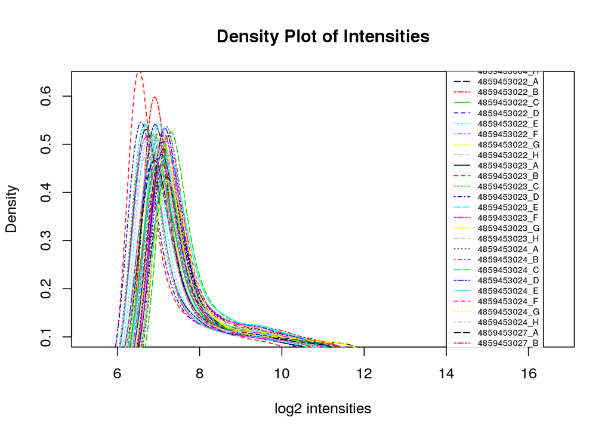

```r
plot(density(log2(rawdata$E[rawdata$genes$Status=="regular",1])),
    xlab="log2 intensities",
    ylab="Density",
    main="Density Plot of Intensities", ylim=c(0.1,0.63))
na=length(rownames(rawdata$target))
for (i in 2:na)
    lines(density(log2(rawdata$E[rawdata$genes$Status=="regular",i])),col=i,lty=i)
legend(14,1,rownames(rawdata$target),lty=1:48,col=1:48,cex=.6)
```

Also evident from the density plot `4849554032_B` looks like an outlier with right skewed distribution of intensities.

## Background correction

```r
rawdata.bgcorrected <- neqc(rawdata)
dim(rawdata.bgcorrected)
```

```
## [1] 24526    48
```

Hence 683 probes were removed, this includes all control probes, BIOTIN(2), CY3_HYB(6), HOUSEKEEPING(1), LABELING(2), LOW_STRINGENCY_HYB(8), NEGATIVE(664)

## Checking for batch effects

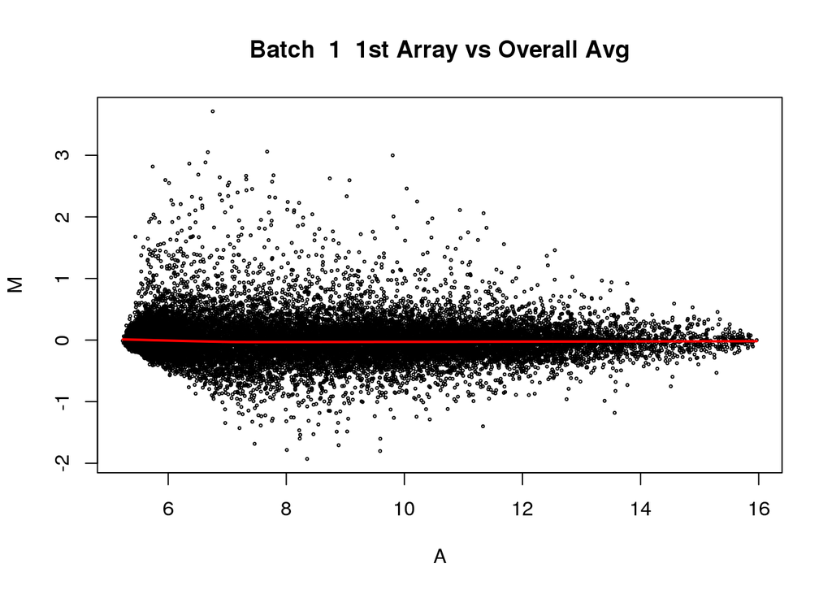

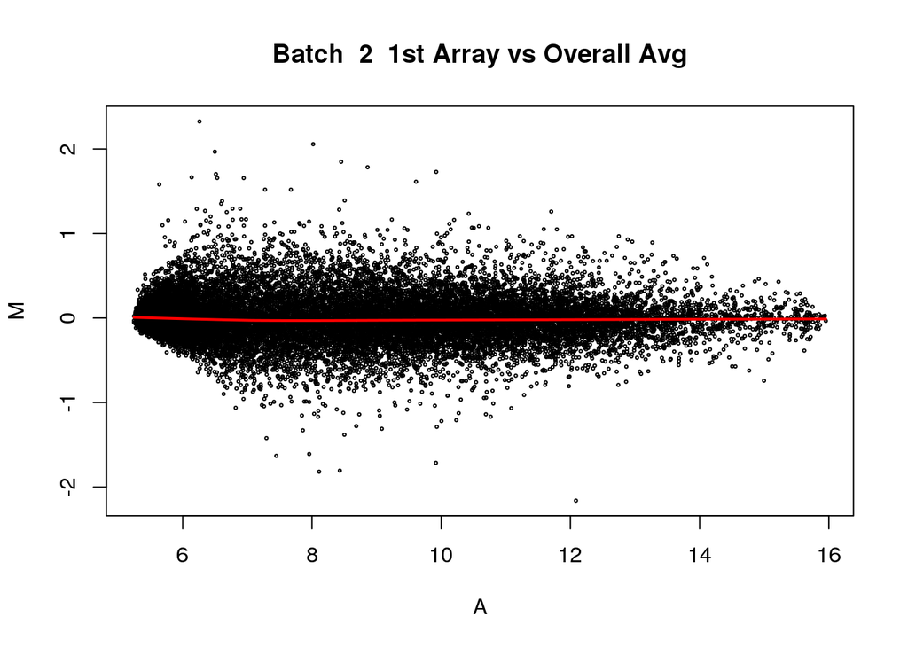

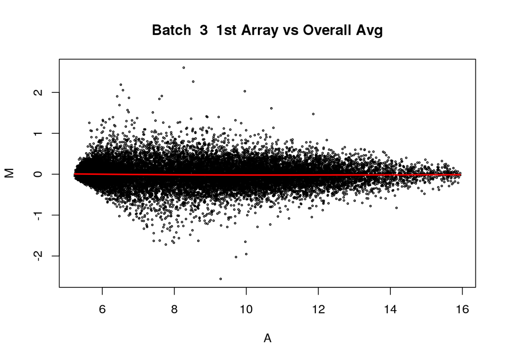

```r
rawdata.bgcorrected <- rawdata.bgcorrected[, order(rawdata.bgcorrected$targets$treatment,                                 rawdata.bgcorrected$targets$time)]
batch               <- unclass(rawdata.bgcorrected$targets$time)
treatment           <- unclass(rawdata.bgcorrected$targets$treatment)

#plot(A,M[,1],ylab="M",cex=.5)
#lines(lowess(A,M[,1]),col=2,lwd=4)
#par(mfrow=c(3,1))
for (i in 1:3) {
  ## Since the arrays are processed like 16 in a batch
  ## I use only samples from the same batch to draw MA plots
  ## Each MA plot is of the 1st array in that batch to avoid drawing 16 x 3 plots
  idx <- rawdata.bgcorrected$targets$time==i
  batchdata <- rawdata.bgcorrected[, idx]
  A <- apply(batchdata$E,1,median)
  M <- batchdata$E-A
  plot(A, M[,1], ylab="M", main=paste("Batch ",i," 1st Array vs Overall Avg"), cex=.3)
  lines(lowess(A,M[,1]),col=2,lwd=2)
}
```

## Before Batch Correction

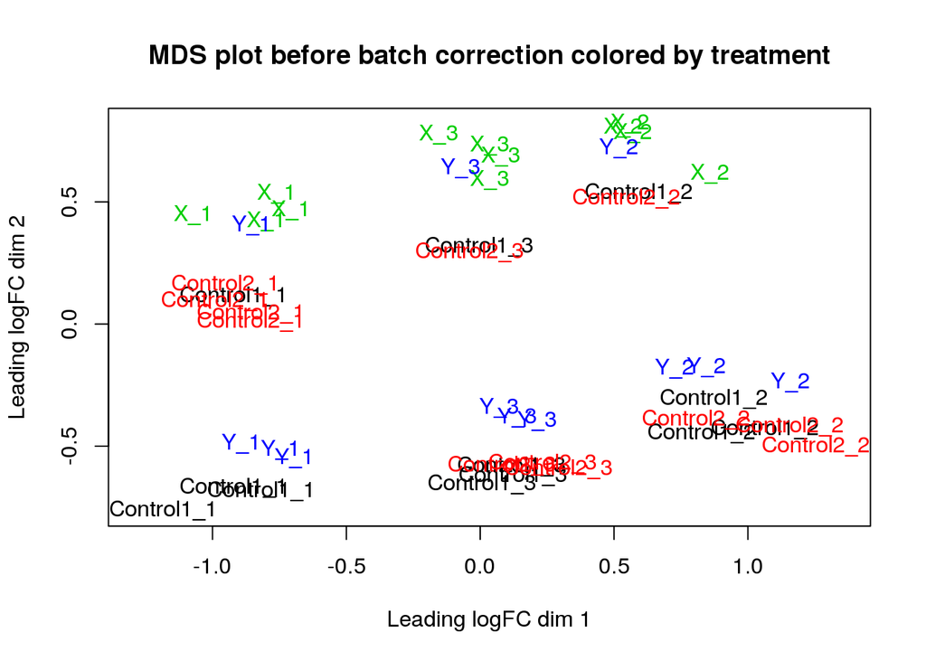

```r
plotMDS(rawdata.bgcorrected,
        labels=paste(rawdata.bgcorrected$targets$treatment, unclass(rawdata.bgcorrected$targets$time), sep="_"),
        col=unclass(rawdata.bgcorrected$targets$treatment),main="MDS plot before batch correction colored by treatment")
```

## Batch-effect Analysis discussion

We replot it by coloring by batches:

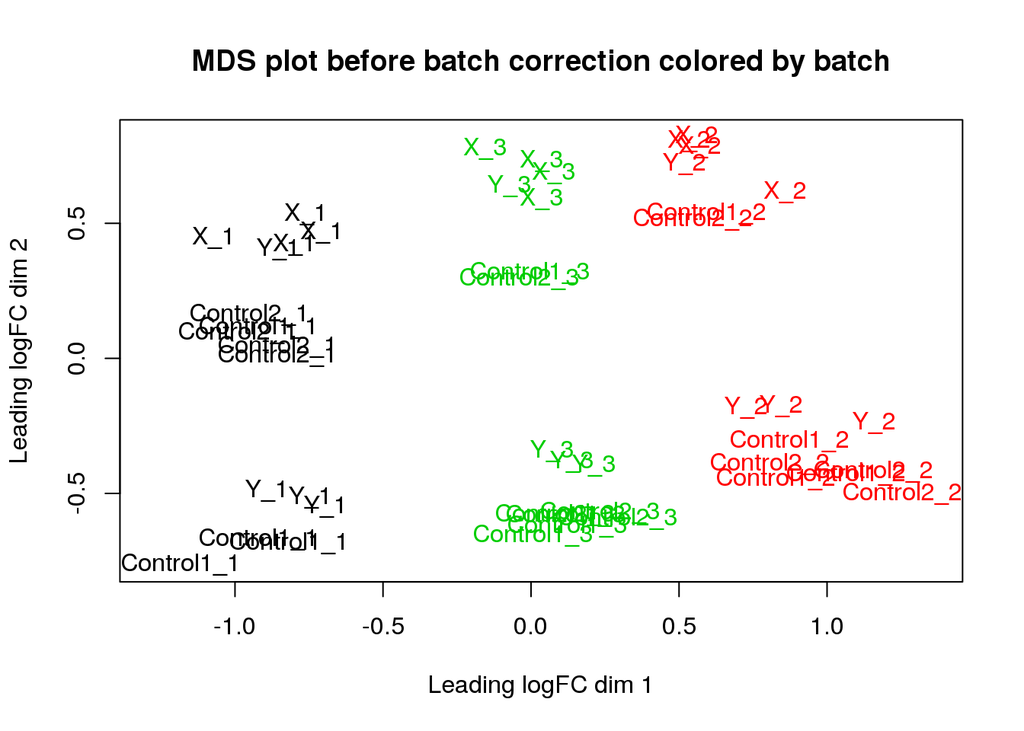

```r
plotMDS(rawdata.bgcorrected,
        labels=paste(rawdata.bgcorrected$targets$treatment, unclass(rawdata.bgcorrected$targets$time), sep="_"),
        col=unclass(rawdata.bgcorrected$targets$time),main="MDS plot before batch correction colored by batch")
```

## Batch Correction

```r
model <- model.matrix(~as.factor(treatment), data=as.data.frame(treatment))
rawdata.bgcorrected.bc <- ComBat(dat=rawdata.bgcorrected$E, batch=batch, mod=model)
```

```
## Found 3 batches
## Adjusting for 3 covariate(s) or covariate level(s)
## Standardizing Data across genes
## Fitting L/S model and finding priors
## Finding parametric adjustments
## Adjusting the Data
```

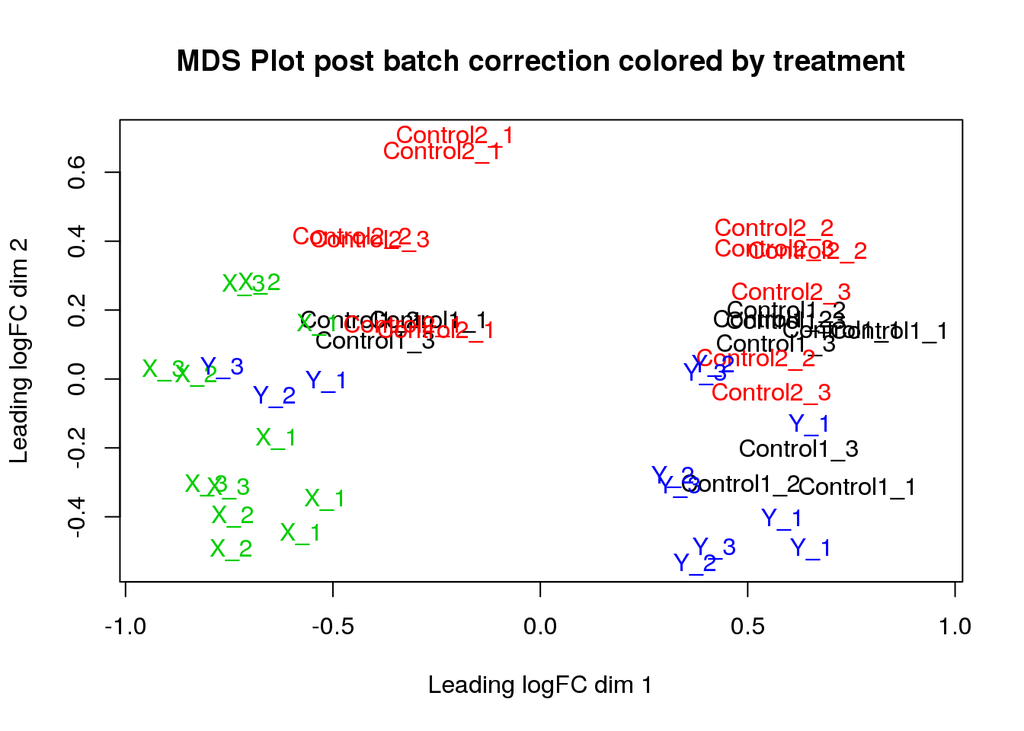

```r
plotMDS(rawdata.bgcorrected.bc,
        labels=paste(rawdata.bgcorrected$targets$treatment, unclass(rawdata.bgcorrected$targets$time), sep="_"),
        col=unclass(rawdata.bgcorrected$targets$treatment), main="MDS Plot post batch correction colored by treatment")
```

```r
model <- model.matrix(~as.factor(treatment), data=as.data.frame(treatment))
rawdata.bgcorrected.bc <- ComBat(dat=rawdata.bgcorrected$E, batch=batch, mod=model)
```

```
## Found 3 batches
## Adjusting for 3 covariate(s) or covariate level(s)
## Standardizing Data across genes
## Fitting L/S model and finding priors
## Finding parametric adjustments
## Adjusting the Data
```

[figure not shown]

```r
plotMDS(rawdata.bgcorrected.bc,
        labels=paste(rawdata.bgcorrected$targets$treatment, unclass(rawdata.bgcorrected$targets$time), sep="_"),
        col=unclass(rawdata.bgcorrected$targets$treatment), main="MDS Plot post batch correction colored by batch")
```

The MDS plot does not show any regular pattern with batches. Thus, batch effects seem to be no longer present.